# Blue Whiting Spawning Habitat Forecast

ICES WGS2D Forecast sheet 01-20210118

Forecast sheet 01-20210118. Issued 18-01-2021, covering the March 2021 spawning distribution.

Prepared by Mark R. Payne, DTU Aqua, Copenhagen, Denmark.

This forecast sheet is the first forecast for the 2021 blue whiting spawning season. An update of this forecast will be issued on or before 12 March 2021. For details, see the Change Log at the bottom of this document.

## Forecast

The spawning habitat for March 2021 is expected to be compressed against the continental shelf edge. Minimal spawning on or to the west of Rockall Plateau is expected (Figure 1). In historical terms, the spawning habitat is forecast to be among the most contracted since 1950 (Figure 2).

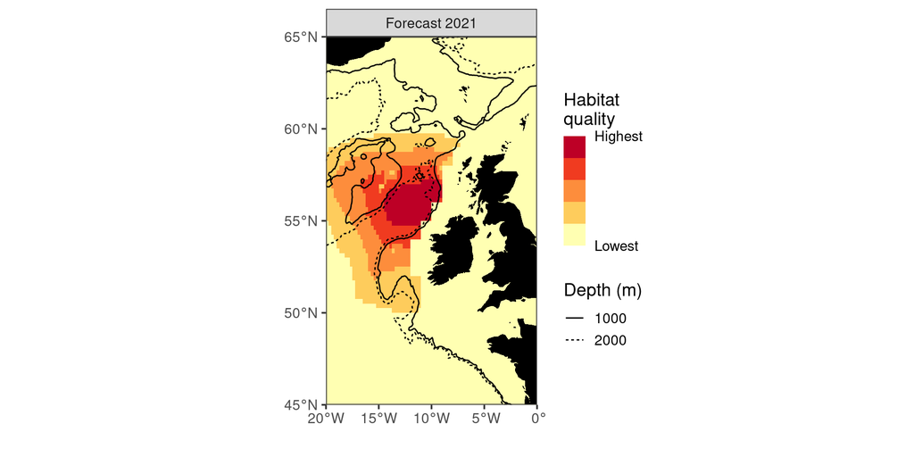

**Figure 1. Forecast spawning habitat for blue whiting in March 2021.** *Habitat is based on the outputs of an ecological niche model of blue whiting larvae distributions and is converted into a metric of habitat quality, from low to high. The 1000m and 2000m isobaths are added for reference.*

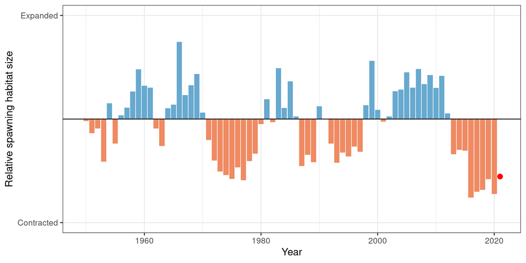

**Figure 2. Time series of spawning habitat characteristics for the northern blue whiting component .** *The time series of spawning habitat maps (e.g. Figure 1) is converted to an indicator of the relative expanded or contracted form of the habitat sizes and plotted. Historical values as show as bars relative to the 1960-2010 climatology (bars - colouring indicates values above or below the mean), while forecast value is shown as a red dot.*

## How to Use this Forecast

This forecast should be used as a broad-scale indicator of the expected spawning habitat of blue whiting in the upcoming spawning season. This forecast can be used in planning monitoring activities on this stock (e.g. the International Blue Whiting Spawning Stock Survey (IBWSSS)) and commercial fishing activities.

## Background

The spawning distribution of blue whiting can vary substantially from year to year (Figures 3). The dominant feature of these changes is a westward expansion away from the shelf-break region west of the European continental shelf onto the Rockall plateau and Hatton bank region.

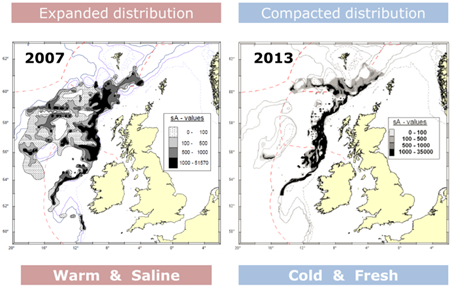

**Figure 3. Spatial distributions of blue whiting from the International Blue Whiting Spawning Stock Survey**. *Two years characterized by different oceanographic conditions (2007 and 2013) are shown. Note the large difference in range occupied towards the west in 2007 compared to 2013.*

Shifts in the spawning distribution of blue whiting have been linked to oceanographic conditions in this region (Hatun et al. 2009) and, in particular, to salinity (Miesner and Payne 2018). Analysis of data from the Continuous Plankton Recorder spanning the period 1951-2005 using an ecological niche model (ENM) has shown that larvae are primarily found within a narrow salinity window between approximately 35.3 and 35.5 (Figure 4). Retrospective predictions of habitat from the ENM (e.g. Figure 5) show good agreement with observations of adult distribution from scientific monitoring surveys (Figure 3).

Salinity in this region is strongly driven by the dynamics of the North Atlantic Sub-polar Gyre (Hatun et al. 2005). This large body of relatively cool, fresher water has significant dynamics of its own, but they tend to vary slowly from year to year. Near-real time observations of these oceanographic properties can be used as reliable estimates of water mass locations in the near-future and thereby the spawning habitat for blue whiting.

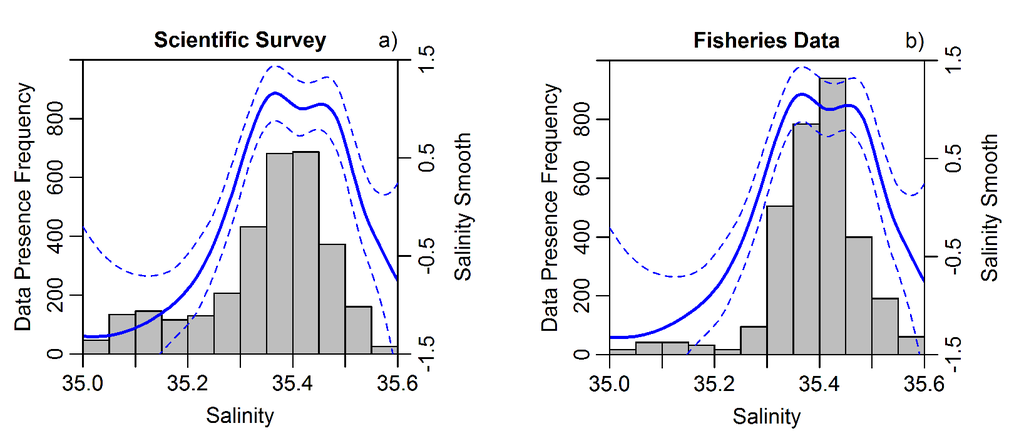

**Figure 4. Relationship between spawning and salinity from independent data sources**. *Presence frequency of spawning blue whiting (number of pixels with presences) a) observed in scientific surveys and b) caught in fisheries is compared to the mean salinity (250-600 m) at which these observations were made (bars). The blue line indicates the modelled smooth function of blue whiting larval-presence obtained from the Species Distribution Model (SDM) based on larval blue whiting catches by the CPR survey, with dashed lines indicating the standard error. Panel a) shows salinity observations from late March / early April, and Panel b) shows data from March.*

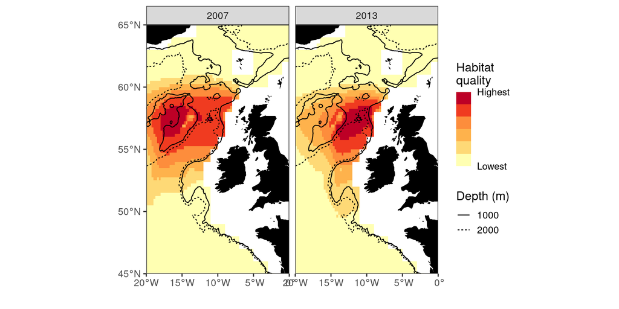

**Figure 5. Modelled spawning habitat for blue whiting in March 2007 and 2013.** *Habitat is based on a model of blue whiting larvae distributions and is converted into a metric of habitat quality, from low to high. The large differences in distribution observed in the IBWSS survey (Figure 3) are reflected here in the available habitat in each year. The 1000m and 2000m isobaths are added for reference.*

## Basis for Forecast

**Table 1. Overview of the basis for the forecast.**

[output not shown]

This forecast is based on a species distribution model developed by Miesner and Payne (2018). The model uses observations of blue whiting larvae captured in the Continuous Plankton Recorder (CPR) as a response variable and links their presence to environmental covariates as explanatory variables, including salinity at spawning depth (250-600m), latitude, day of year, solar elevation angle and bathymetry. Salinity at spawning depth was shown to be the most important environmental factor that varied inter-annually, and drives the westward expansion of spawning habitat. The model has been verified by cross-validation with the CPR observations. Furthermore, the sensitivity of the larval response to salinity obtained from CPR data shows good agreement with independent distribution data sets obtained from both commercial fishers and scientific surveys (Figure 4).

Forecasts of the physical environment (and specifically salinity at spawning depth) are derived by assuming that the most recently observed state of the environment (anomaly) will persist until at least the next spawning period and possibly beyond.

## Quality Considerations

This forecast is a prediction of the potential spawning habitat of the species and should not be interpreted as a direct forecast of distribution. While there is a relationship between the two, it is important to remember that the actual distribution of spawning may not utilise all of the potential spawning habitat (e.g. due to migration dynamics, density-dependent processes or other biotic factors). On the other hand, it is unlikely that spawning can occur in the absence of suitable habitat. The ability of this forecast to represent distribution is therefore asymmetrical.

The forecast is based on observations of larvae, and therefore reflects the distribution of spawning activity. However, pre- and post-spawning fish are also migrating to and from the spawning grounds during this time, and although they are not reflected in this forecast, they may be observed in both scientific surveys and commercial fisheries. The forecast skill is therefore strongest in the east-west direction (perpendicular to the axis of migration).

Forecasts of the physical environment in this region are currently based on persistence i.e. the assumption that, for example, next year will be the same as this year. While the dynamics in this region are typically slow, they have occasionally moved rapidly, which could cause discrepancies between forecasted and observed spawning habitat. However, such events are considered relatively rare and analysis of the forecast skill has shown that this is a valid assumption.

## Forecast Skill Assessment

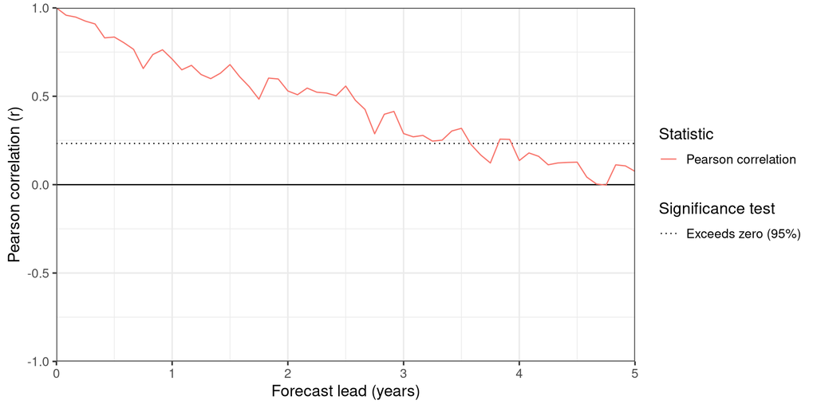

## For More Information

For more information, contact Mark R. Payne, DTU-Aqua, http://www.staff.dtu.dk/mpay. The latest version of this and other forecasts can be found on the website http://fishforecasts.dtu.dk. Code used to generate this forecast is available from the WGS2D GitHub repository, https://github.com/ices-eg/wg_WGS2D in the directory “01_Blue_whiting_spawning_distribution”.

## Acknowledgements

The research leading to these results has received funding from the European Union 7th Framework Programme (FP7 2007–2013) under grant agreement number 308299 (NACLIM) and the Horizon 2020 research and innovation programme under grant agreement number 727852 (Blue-Action). We thank Åge Høines and the members of the WGIPS group responsible for planning the IBWSS survey for input.

## References

Good, S. A., M. J. Martin and N. A. Rayner. (2013). EN4: quality controlled ocean temperature and salinity profiles and monthly objective analyses with uncertainty estimates, Journal of Geophysical Research: Oceans, 118, 6704-6716, doi:10.1002/2013JC009067

Hátún, H., Sandø, A. B., Drange, H., Hansen, B., and Valdimarsson, H. (2005). Influence of the Atlantic subpolar gyre on the thermohaline circulation. Science, 309(5742), 1841–4. doi:10.1126/science.1114777

Hátún H., Payne, M.R., and Jacobsen, J.A. (2009) The North Atlantic subpolar gyre regulates the spawning distribution of blue whiting (*Micromesistius poutassou*). Canadian Journal of Fisheries and Aquatic Sciences 66: 759–770 doi:10.1139/F09-037

Miesner, A.K., and Payne, M.R. (2018) Oceanographic variability shapes the spawning distribution of blue whiting (*Micromesistius poutassou*). Fisheries Oceanography, 27(6), 623–638. doi:10.1111/fog.12382

Pointin, Fabien; Payne, Mark R (2014): A Resolution to the Blue Whiting (Micromesistius poutassou) Population Paradox? PLoS ONE, 9(9), e106237, https://doi.org/10.1371/journal.pone.0106237

## Change Log

- 2021018 - Shift to use of PredEng pipeline to generate model predictions. Use of PCA to synthesise ENM maps. Addition of more oceanographic data sets and “consensus” visualisation.
- 2020 - No forecast was issued in 2020 due to practical limitations associated with the global COVID-19 pandemic.
- 20190103 Updated. Forecast verification for 2018 included.
- 20180831 Updated to 2019 forecast.
- 20180301.v03.0 Updated EN4 data set to 4.2.1. Added forecast expressed as an anomaly. Added “forecast basis” summary table. Added supplementary information comparing with survey track and current oceanographic state. Add PSY4 reanalysis product into mix.
- 20180117.v02.1 Minor update to include salinity contours in Figure 2.
- 20180115.v02 Updated to October 2017 oceanography. Visual improvements.
- 20170614.v01 Initial draft version

## Supplementary Information

### S1. Oceanographic Conditions

To provide a more detailed insight into the current oceanographic conditions driving the distribution, the current state of salinity at the spawning depth is shown below. In particular, the well-reported salinity anomalies in the North Atlantic Sub-Polar Gyre (upper-left side of panel b) are having a clear effect on the spawning region of blue whiting and compressing the spawning habitat.

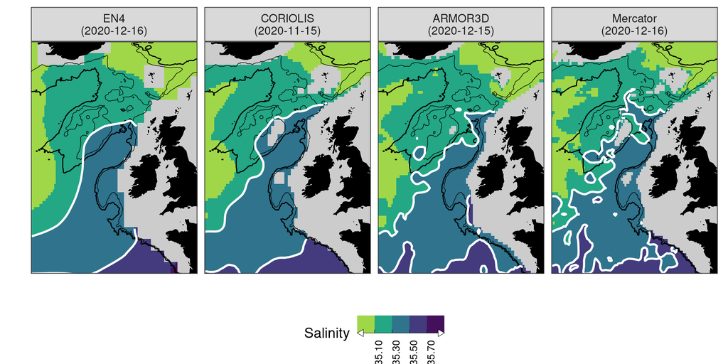

**Figure S2.1 Comparison of alternative salinity datasets.** *The most recent salinity estimates at spawning depth (250-600m) from two observationally-based analysis products (EN4, CORIOLIS) and two model-based ocean reanalyses (ARMORD3D, Mercator) are plotted. The while isohalines define the suitable salinity window (35.3 - 35.5). The 1000m and 2000m isobaths are added for reference. Panels are labelled with the name of the data product and the date of the most recent estimate. All datasources are interpolated onto a common 0.25 degree grid.*

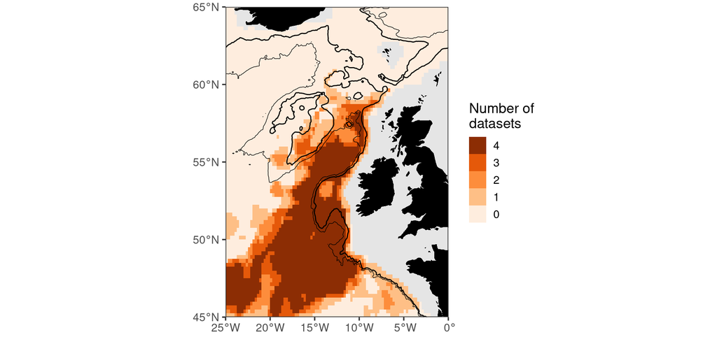

**Figure S2.2 Data source consensus** *The number of datasets in a pixel where the most recent salinity estimate is within the suitable salinity window (35.3 - 35.5) is plotted. The 1000m and 2000m isobaths are added for reference.*

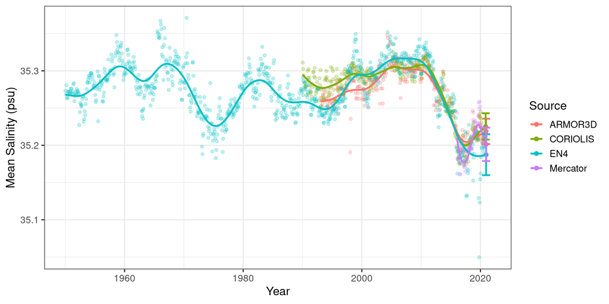

**Figure S2.3. Time series of salinity in the spawning area.** *Monthly salinity at spawning depth (250-600m) from two observationally-based analysis products (EN4, CORIOLIS) and two model-based ocean reanalyses (ARMORD3D, Mercator). Points are plotted for each individual month, while a line smooths each individual data source and corrects for any seasonal cycle. The most recent estimate for each source is plotted as a point with 95% confidence interval (after correcting for the seasonal cycle).*

## License Information

This work by Mark R. Payne is licensed under a Creative Commons Attribution-NonCommercial-ShareAlike 3.0 Unported License. For details, see http://creativecommons.org/licenses/by-nc-sa/3.0/deed.en_US. Basically, this means that you are free to “share” and “remix” for non-commercial purposes as you see fit, so long as you “attribute” me for my contribution. Derivatives can be distributed under the same or similar license.

This work is an experimental research forecast product and comes with ABSOLUTELY NO WARRANTY or support. Any use of these forecasts is done at the risk of the user.

[figure not shown]